# Peer Assessment 1

Hafidz Zulkifli

Monday, May 18, 2015

Assignment

This assignment will be described in multiple parts. You will need to write a report that answers the questions detailed below. Ultimately, you will need to complete the entire assignment in a single R markdown document that can be processed by knitr and be transformed into an HTML file.

Throughout your report make sure you always include the code that you used to generate the output you present. When writing code chunks in the R markdown document, always use echo = TRUE so that someone else will be able to read the code. This assignment will be evaluated via peer assessment so it is essential that your peer evaluators be able to review the code for your analysis.

For the plotting aspects of this assignment, feel free to use any plotting system in R (i.e., base, lattice, ggplot2)

Fork/clone the GitHub repository created for this assignment. You will submit this assignment by pushing your completed files into your forked repository on GitHub. The assignment submission will consist of the URL to your GitHub repository and the SHA-1 commit ID for your repository state.

1. Loading and preprocessing the data

```r
activity <- read.csv("D:/Self_Development/Coursera - JHU/5. Reproducible Research/1/activity.csv" )
no_na_activity <- activity[complete.cases(activity),]
```

2. What is mean total number of steps taken per day?

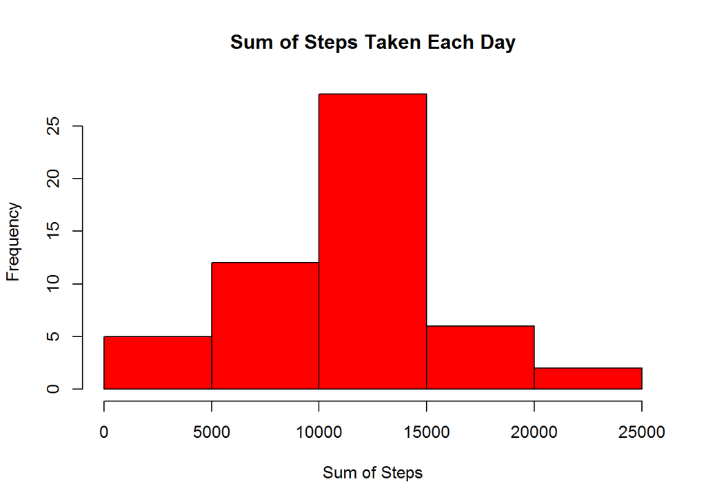

```r
library(plyr)
step_stat <- ddply(no_na_activity,~date,summarise,sum=sum(steps),mean=mean(steps),median=median(steps))
hist(step_stat$sum,  main="Sum of Steps Taken Each Day", col="red", xlab="Sum of Steps")
```

```r
step_stat$mean
```

```
##  [1]  0.4375000 39.4166667 42.0694444 46.1597222 53.5416667 38.2465278
##  [7] 44.4826389 34.3750000 35.7777778 60.3541667 43.1458333 52.4236111
## [13] 35.2048611 52.3750000 46.7083333 34.9166667 41.0729167 36.0937500
## [19] 30.6284722 46.7361111 30.9652778 29.0104167  8.6527778 23.5347222
## [25] 35.1354167 39.7847222 17.4236111 34.0937500 53.5208333 36.8055556
## [31] 36.7048611 36.2465278 28.9375000 44.7326389 11.1770833 43.7777778
## [37] 37.3784722 25.4722222  0.1423611 18.8923611 49.7881944 52.4652778
## [43] 30.6979167 15.5277778 44.3993056 70.9270833 73.5902778 50.2708333
## [49] 41.0902778 38.7569444 47.3819444 35.3576389 24.4687500
```

```r
step_stat$median
```

```
##  [1] 0 0 0 0 0 0 0 0 0 0 0 0 0 0 0 0 0 0 0 0 0 0 0 0 0 0 0 0 0 0 0 0 0 0 0
## [36] 0 0 0 0 0 0 0 0 0 0 0 0 0 0 0 0 0 0
```

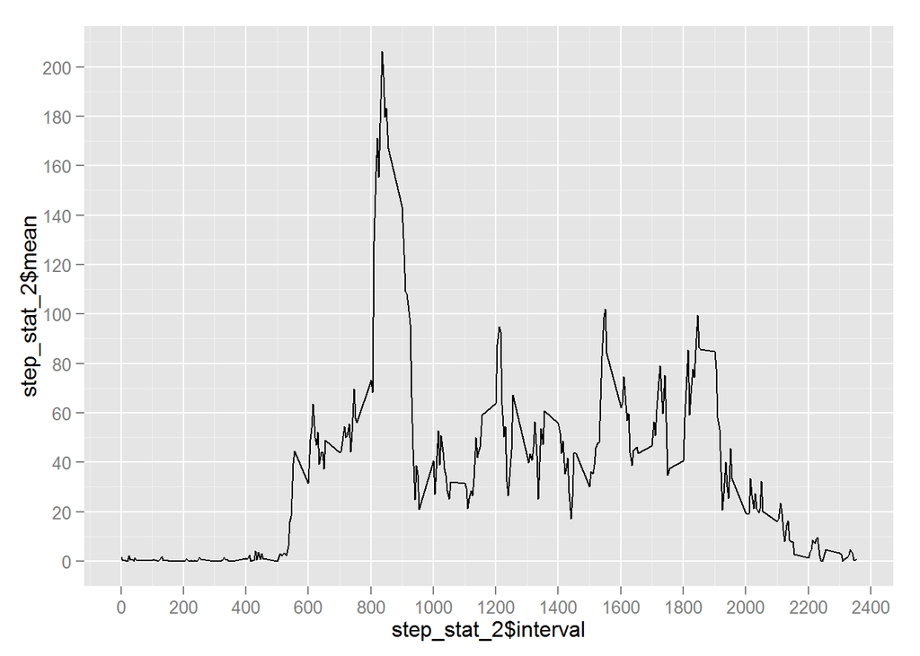

```r
step_stat_2 <- ddply(no_na_activity,.(interval),summarise,sum=sum(steps),mean=mean(steps),median=median(steps))
library(ggplot2)
library(scales)
ggplot(step_stat_2, aes(step_stat_2$interval,step_stat_2$mean )) + geom_line() + scale_x_continuous(breaks=pretty_breaks(n=10)) + scale_y_continuous(breaks=pretty_breaks(n=10))
```